# A.Sauk_Biol612_Homework3

Alexandra Sauk

2020-01-27

#Part 1 - ANOVAs

## Question 1 & 2

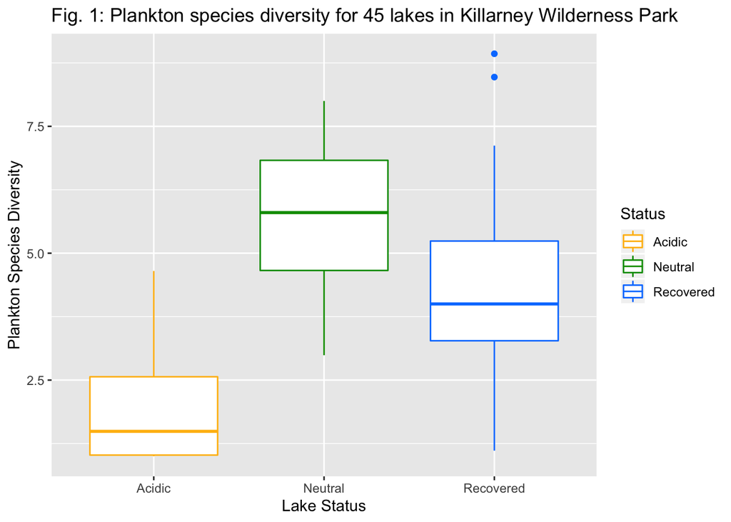

```r
library("ggplot2")

Kdata<-read.csv("Killarney.csv")

Lake<-Kdata$Lake
Diversity<-Kdata$Diversity
Status<-Kdata$status

par(mar=c(8.5,6.5,4.1,3.1), mgp=c(3,1,0))
ggplot(Kdata, aes(x=Status, y=Diversity, color=Status)) + geom_boxplot() + labs(y="Plankton Species Diversity", x="Lake Status", title = "Fig. 1: Plankton species diversity for 45 lakes in Killarney Wilderness Park") + scale_color_manual(values = c("#ffbb0e", "#009a00", "#007fff"))
```

From the boxplot, it does look like there are differences in plankton diversity between the three lake types, with acid lakes have the least diversity and the neutral, never acid damaged lakes have the greatest diversity. The recovered lakes appear to increases in diversity nearing the levels of diversity seen in the neutral lakes.

## Question 3

```r
k.fit=aov(Diversity~Status, data = Kdata)
summary(k.fit)
```

```
##             Df Sum Sq Mean Sq F value   Pr(>F)
## Status       2  97.41   48.70   16.41 5.43e-06 ***
## Residuals   42 124.68    2.97
## ---
## Signif. codes:  0 '***' 0.001 '**' 0.01 '*' 0.05 '.' 0.1 ' ' 1
```

## Question 5

The observed test statistic is F value of 16.41 and the p value is p=5.43e-06.

## Question 6

There is a significant difference in species richness amoung the three lake types.

## Question 7

```r
TukeyHSD(aov(Diversity~Status, data = Kdata))
```

```
##   Tukey multiple comparisons of means
##     95% family-wise confidence level
##
## Fit: aov(formula = Diversity ~ Status, data = Kdata)
##
## $Status
##                        diff       lwr      upr     p adj
## Neutral-Acidic     3.603068  1.874854 5.331282 0.0000253
## Recovered-Acidic   2.418485  1.016843 3.820127 0.0004023
## Recovered-Neutral -1.184583 -3.017179 0.648012 0.2695118
```

## Question 8

Based on the Tukey HSD test, the species diversity is significantly different between the acid lakes and the recovered lakes as well as the acid lakes and the neutral lakes. The neutral and recovered lakes do not differ significantly in terms of their species diversity.

## Question 9

## Shapiro-Wilk’s test

```r
shapiro.test(k.fit$residuals)
```

```
##
##  Shapiro-Wilk normality test
##
## data:  k.fit$residuals
## W = 0.93501, p-value = 0.01415
```

Since p=0.01415, we reject the null hypothesis that the residuals are normally distributed. Thus, the data do not meet the assumption of normality required for the ANOVA.

## Levene’s test

```r
library("car")
str(Kdata)
```

```
## 'data.frame':    45 obs. of  3 variables:
##  $ Lake     : Factor w/ 45 levels "A.Y. Jackson",..: 2 8 9 10 13 15 24 26 28 31 ...
##  $ status   : Factor w/ 3 levels "Acidic","Neutral",..: 1 1 1 1 1 1 1 1 1 1 ...
##  $ Diversity: num  2 4.65 4.09 1.11 2.06 1.02 2.57 1.03 1 1.75 ...
```

```r
leveneTest(Diversity, Status)
```

```
## Levene's Test for Homogeneity of Variance (center = median)
##       Df F value Pr(>F)
## group  2  0.9977 0.3773
##       42
```

Since p=0.3773, we do not reject the null hypothesis that the variances in each groups is the same. Thus, the data meets the assumption that the variances in each group is the same.

## Question 10

## Two factor ANOVA - tobacco and alcohol

```r
Edata<-read.csv("esoph.csv")

Age<-Edata$Age
Alcohol<-Edata$Alcohol
Tobacco<-Edata$Tobacco
ncases<-Edata$ncases
ncontrols<-Edata$ncontrols

e.fit1<-aov(ncases~Tobacco*Alcohol)

summary(e.fit1)
```

```
##                 Df Sum Sq Mean Sq F value Pr(>F)
## Tobacco          3   41.6  13.874   1.851  0.146
## Alcohol          3   46.8  15.596   2.081  0.110
## Tobacco:Alcohol  9   31.5   3.501   0.467  0.892
## Residuals       72  539.5   7.494
```

Based on the results of the two factor ANOVA, neither alcohol consumption or tobacco use on their own or together, signficantly affect on incidences of esophageal cancer as all of the p values are above 0.05.

## Question 11

## Two factor ANOVA - tobacco and age

```r
e.fit2<-aov(ncases~Tobacco*Age)

summary(e.fit2)
```

```
##             Df Sum Sq Mean Sq F value   Pr(>F)
## Tobacco      3  41.62   13.87   3.406   0.0228 *
## Age          5 272.55   54.51  13.384 6.23e-09 ***
## Tobacco:Age 15  84.62    5.64   1.385   0.1822
## Residuals   64 260.67    4.07
## ---
## Signif. codes:  0 '***' 0.001 '**' 0.01 '*' 0.05 '.' 0.1 ' ' 1
```

```r
TukeyHSD(e.fit2)
```

```
##   Tukey multiple comparisons of means
##     95% family-wise confidence level
##
## Fit: aov(formula = ncases ~ Tobacco * Age)
##
## $Tobacco
##                      diff       lwr         upr     p adj
## 10-19-0-9g/day -0.8333333 -2.370109  0.70344196 0.4853668
## 20-29-0-9g/day -1.6000000 -3.211784  0.01178353 0.0524043
## 30+-0-9g/day   -1.7000000 -3.311784 -0.08821647 0.0348451
## 20-29-10-19    -0.7666667 -2.378450  0.84511686 0.5947724
## 30+-10-19      -0.8666667 -2.478450  0.74511686 0.4927118
## 30+-20-29      -0.1000000 -1.783453  1.58345299 0.9986155
##
## $Age
##                   diff        lwr        upr     p adj
## 35-44-25-34  0.5266667 -1.6382744  2.6916077 0.9794889
## 45-54-25-34  2.8461111  0.7152658  4.9769564 0.0028395
## 55-64-25-34  4.7211111  2.5902658  6.8519564 0.0000002
## 65-74-25-34  3.5933333  1.4283923  5.7582744 0.0001062
## 75+-25-34    0.8771717 -1.4763673  3.2307107 0.8816351
## 45-54-35-44  2.3194444  0.1885991  4.4502898 0.0251086
## 55-64-35-44  4.1944444  2.0635991  6.3252898 0.0000035
## 65-74-35-44  3.0666667  0.9017256  5.2316077 0.0013005
## 75+-35-44    0.3505051 -2.0030340  2.7040441 0.9978779
## 55-64-45-54  1.8750000 -0.2211951  3.9711951 0.1053407
## 65-74-45-54  0.7472222 -1.3836231  2.8780676 0.9060158
## 75+-45-54   -1.9689394 -4.2911535  0.3532747 0.1422116
## 65-74-55-64 -1.1277778 -3.2586231  1.0030676 0.6306234
## 75+-55-64   -3.8439394 -6.1661535 -1.5217253 0.0001115
## 75+-65-74   -2.7161616 -5.0697006 -0.3626226 0.0145751
##
## $`Tobacco:Age`
##                                        diff          lwr        upr     p adj
## 10-19:25-34-0-9g/day:25-34     2.500000e-01  -5.17250361  5.6725036 1.0000000
## 20-29:25-34-0-9g/day:25-34     1.720846e-15  -5.85697331  5.8569733 1.0000000
## 30+:25-34-0-9g/day:25-34       5.828671e-16  -5.42250361  5.4225036 1.0000000
## 0-9g/day:35-44-0-9g/day:25-34  5.000000e-01  -4.92250361  5.9225036 1.0000000
## 10-19:35-44-0-9g/day:25-34     1.000000e+00  -4.42250361  6.4225036 1.0000000
## 20-29:35-44-0-9g/day:25-34     7.500000e-01  -4.67250361  6.1725036 1.0000000
```

[output cut: 255 more lines]

```
## 30+:65-74-20-29:65-74         -1.833333e+00  -7.69030664  4.0236400 0.9999250
## 0-9g/day:75+-20-29:65-74      -1.000000e+00  -6.42250361  4.4225036 1.0000000
## 10-19:75+-20-29:65-74         -1.250000e+00  -6.67250361  4.1725036 0.9999997
## 20-29:75+-20-29:65-74         -2.500000e+00 -11.07373102  6.0737310 0.9999772
## 30+:75+-20-29:65-74           -1.500000e+00  -8.14118349  5.1411835 0.9999998
## 0-9g/day:75+-30+:65-74         8.333333e-01  -5.02363997  6.6903066 1.0000000
## 10-19:75+-30+:65-74            5.833333e-01  -5.27363997  6.4403066 1.0000000
## 20-29:75+-30+:65-74           -6.666667e-01  -9.52157798  8.1882446 1.0000000
## 30+:75+-30+:65-74              3.333333e-01  -6.66708873  7.3337554 1.0000000
## 10-19:75+-0-9g/day:75+        -2.500000e-01  -5.67250361  5.1725036 1.0000000
## 20-29:75+-0-9g/day:75+        -1.500000e+00 -10.07373102  7.0737310 1.0000000
## 30+:75+-0-9g/day:75+          -5.000000e-01  -7.14118349  6.1411835 1.0000000
## 20-29:75+-10-19:75+           -1.250000e+00  -9.82373102  7.3237310 1.0000000
## 30+:75+-10-19:75+             -2.500000e-01  -6.89118349  6.3911835 1.0000000
## 30+:75+-20-29:75+              1.000000e+00  -8.39205176 10.3920518 1.0000000
```

Based on the results of this two factor ANOVA, tobacco use has a signficant affect on incidences of esophageal cancer as p=0.0228 but based on the Tukey test, the effect of tobacco use is only significant when comparing cancer rates between the 0-9g and 30+g per day users (p=0.0348451). Age has a signficant affect overall on incidences of esophageal cancer as p=6.23e-09, with significant between group differences shown below. There is no significant interaction between age and tobacco use.

Age groups p-value 45-54-25-34 0.0028395 55-64-25-34 0.0000002 65-74-25-34 0.0001062 45-54-35-44 0.0251086 55-64-35-44 0.0000035 65-74-35-44 0.0013005 75+-55-64 0.0001115 75+-65-74 0.0145751

## Question 12

## Two factor ANOVA - alcohol and age

```r
e.fit3<-aov(ncases~Alcohol*Age)

summary(e.fit3)
```

```
##             Df Sum Sq Mean Sq F value   Pr(>F)
## Alcohol      3  46.87   15.62   4.201  0.00892 **
## Age          5 267.03   53.41  14.361 2.02e-09 ***
## Alcohol:Age 15 107.56    7.17   1.928  0.03633 *
## Residuals   64 238.00    3.72
## ---
## Signif. codes:  0 '***' 0.001 '**' 0.01 '*' 0.05 '.' 0.1 ' ' 1
```

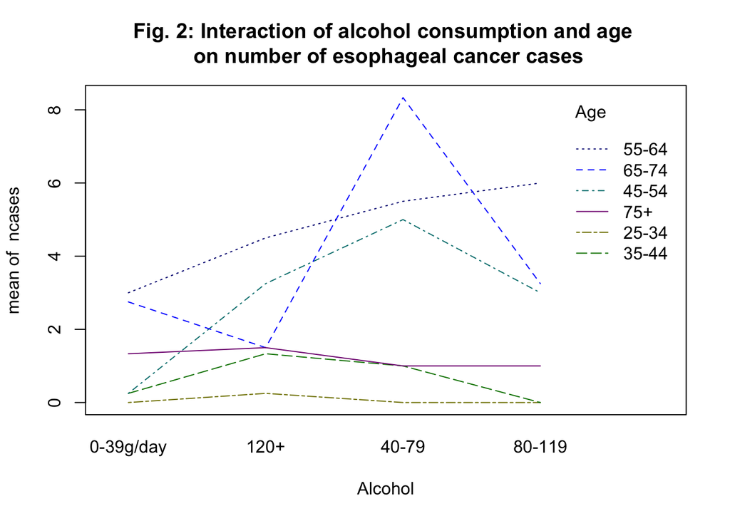

```
## integer(0)
```

```r
interaction.plot(Alcohol, Age, ncases, legend = T, col=c("#808000","#008000","#008080","#000080","#0000FF","#800080")) + title(main = "Fig. 2: Interaction of alcohol consumption and age \n on number of esophageal cancer cases")
```

Based on the results of this two factor ANOVA, alcohol consumption has a signficant affect on incidences of esophageal cancer as p=0.00892 and age has a signficant affect on incidences of esophageal cancer as p=2.02e-09. There is also a significant interaction between age and alcohol asumption with a p=0.03633. ALcohol consumption appears to interact the most with the three ages groups between 45 and 74 years of age.

#Part 2 - Regression and Correlation

## Question 13

```r
mtcars
```

```
##                      mpg cyl  disp  hp drat    wt  qsec vs am gear carb
## Mazda RX4           21.0   6 160.0 110 3.90 2.620 16.46  0  1    4    4
## Mazda RX4 Wag       21.0   6 160.0 110 3.90 2.875 17.02  0  1    4    4
## Datsun 710          22.8   4 108.0  93 3.85 2.320 18.61  1  1    4    1
## Hornet 4 Drive      21.4   6 258.0 110 3.08 3.215 19.44  1  0    3    1
## Hornet Sportabout   18.7   8 360.0 175 3.15 3.440 17.02  0  0    3    2
## Valiant             18.1   6 225.0 105 2.76 3.460 20.22  1  0    3    1
## Duster 360          14.3   8 360.0 245 3.21 3.570 15.84  0  0    3    4
## Merc 240D           24.4   4 146.7  62 3.69 3.190 20.00  1  0    4    2
## Merc 230            22.8   4 140.8  95 3.92 3.150 22.90  1  0    4    2
## Merc 280            19.2   6 167.6 123 3.92 3.440 18.30  1  0    4    4
## Merc 280C           17.8   6 167.6 123 3.92 3.440 18.90  1  0    4    4
## Merc 450SE          16.4   8 275.8 180 3.07 4.070 17.40  0  0    3    3
## Merc 450SL          17.3   8 275.8 180 3.07 3.730 17.60  0  0    3    3
## Merc 450SLC         15.2   8 275.8 180 3.07 3.780 18.00  0  0    3    3
## Cadillac Fleetwood  10.4   8 472.0 205 2.93 5.250 17.98  0  0    3    4
## Lincoln Continental 10.4   8 460.0 215 3.00 5.424 17.82  0  0    3    4
## Chrysler Imperial   14.7   8 440.0 230 3.23 5.345 17.42  0  0    3    4
## Fiat 128            32.4   4  78.7  66 4.08 2.200 19.47  1  1    4    1
## Honda Civic         30.4   4  75.7  52 4.93 1.615 18.52  1  1    4    2
## Toyota Corolla      33.9   4  71.1  65 4.22 1.835 19.90  1  1    4    1
## Toyota Corona       21.5   4 120.1  97 3.70 2.465 20.01  1  0    3    1
## Dodge Challenger    15.5   8 318.0 150 2.76 3.520 16.87  0  0    3    2
## AMC Javelin         15.2   8 304.0 150 3.15 3.435 17.30  0  0    3    2
## Camaro Z28          13.3   8 350.0 245 3.73 3.840 15.41  0  0    3    4
## Pontiac Firebird    19.2   8 400.0 175 3.08 3.845 17.05  0  0    3    2
## Fiat X1-9           27.3   4  79.0  66 4.08 1.935 18.90  1  1    4    1
## Porsche 914-2       26.0   4 120.3  91 4.43 2.140 16.70  0  1    5    2
## Lotus Europa        30.4   4  95.1 113 3.77 1.513 16.90  1  1    5    2
## Ford Pantera L      15.8   8 351.0 264 4.22 3.170 14.50  0  1    5    4
## Ferrari Dino        19.7   6 145.0 175 3.62 2.770 15.50  0  1    5    6
## Maserati Bora       15.0   8 301.0 335 3.54 3.570 14.60  0  1    5    8
## Volvo 142E          21.4   4 121.0 109 4.11 2.780 18.60  1  1    4    2
```

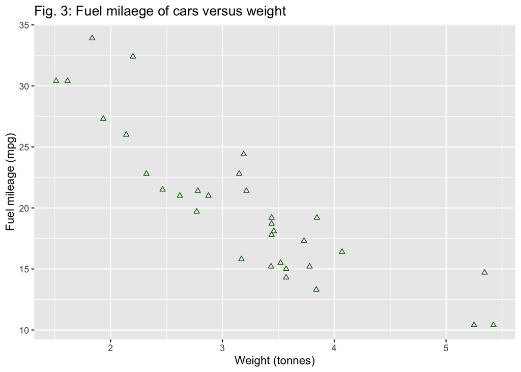

```r
library("ggplot2")
ggplot(mtcars, aes(x=mtcars$wt, y=mtcars$mpg)) + geom_point(shape = 2, color=("dark green")) + labs(x="Weight (tonnes)", y="Fuel mileage (mpg)", title = "Fig. 3: Fuel milaege of cars versus weight")
```

Fuel mileage does appear to depend on vehicle weight as there is a negative trend in fuel mileage as weight increases.

## Linear regression

```r
car.fit<-glm(mpg~wt, data=mtcars)
summary.lm(car.fit)
```

```
##
## Call:
## glm(formula = mpg ~ wt, data = mtcars)
##
## Residuals:
##     Min      1Q  Median      3Q     Max
## -4.5432 -2.3647 -0.1252  1.4096  6.8727
##
## Coefficients:
##             Estimate Std. Error t value Pr(>|t|)
## (Intercept)  37.2851     1.8776  19.858  < 2e-16 ***
## wt           -5.3445     0.5591  -9.559 1.29e-10 ***
## ---
## Signif. codes:  0 '***' 0.001 '**' 0.01 '*' 0.05 '.' 0.1 ' ' 1
##
## Residual standard error: 3.046 on 30 degrees of freedom
## Multiple R-squared:  0.7528, Adjusted R-squared:  0.7446
## F-statistic: 91.38 on 1 and 30 DF,  p-value: 1.294e-10
```

## Add regression line

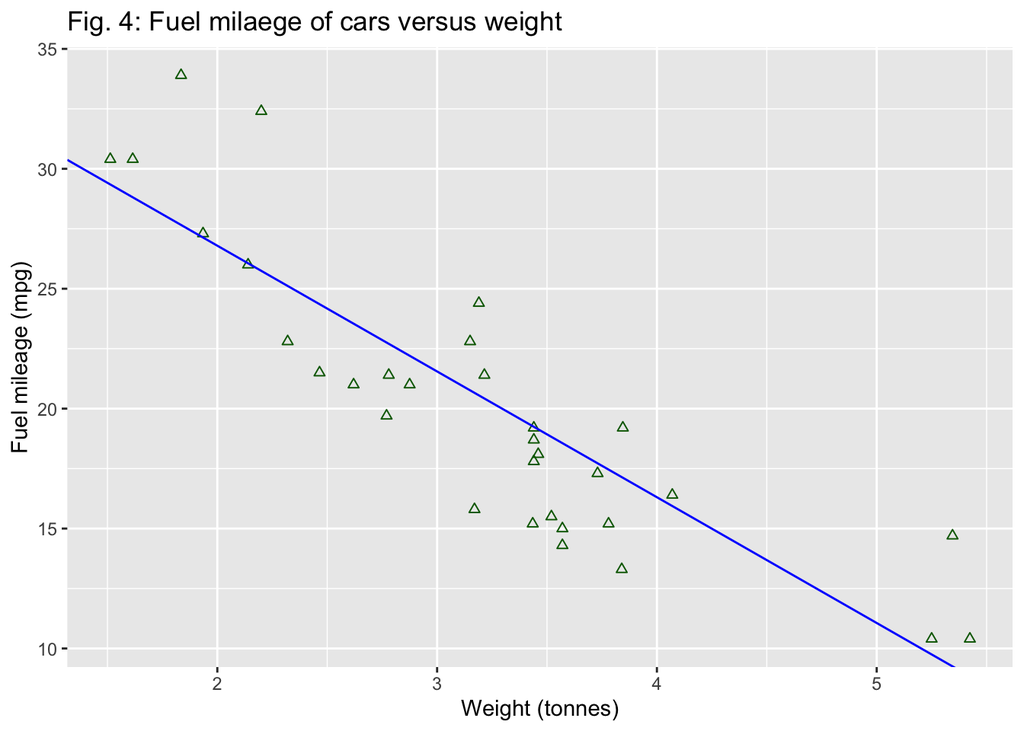

```r
ggplot(mtcars, aes(x=mtcars$wt, y=mtcars$mpg)) + geom_point(shape = 2, color=("dark green")) + labs(x="Weight (tonnes)", y="Fuel mileage (mpg)", title = "Fig. 4: Fuel milaege of cars versus weight") + geom_abline(intercept = 37.2851, slope = -5.2445, color="blue")
```

## Significance

There is a significant negative correlation between the fuel mileage and the weight of cars with p=1.294e-10.

## Question 14

```r
mtcars
```

[output not shown]

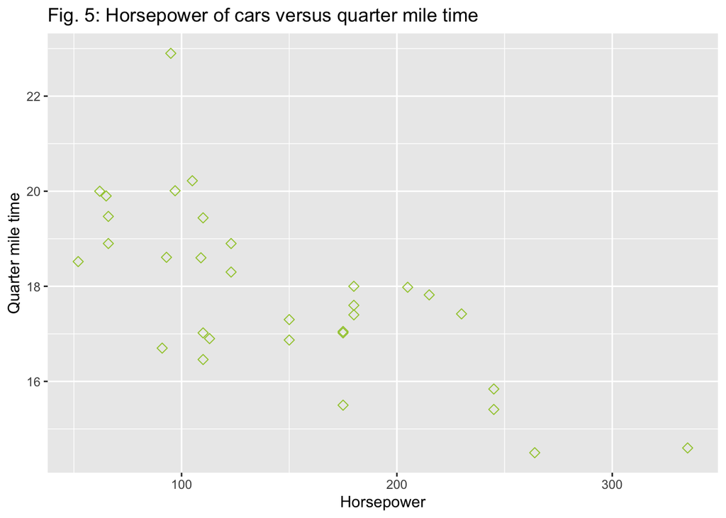

```r
library("ggplot2")
ggplot(mtcars, aes(x=mtcars$hp, y=mtcars$qsec)) + geom_point(shape = 5, color=("#A2C93A"), size=2) + labs(x="Horsepower", y="Quarter mile time", title = "Fig. 5: Horsepower of cars versus quarter mile time")
```

Quarter mile time does appear to depend on horsepower as there is a negative trend in quartner mile time as horsepower increases.

## Linear regression

```r
car.fit2<-glm(qsec~hp, data=mtcars)
summary.lm(car.fit2)
```

```
##
## Call:
## glm(formula = qsec ~ hp, data = mtcars)
##
## Residuals:
##     Min      1Q  Median      3Q     Max
## -2.1766 -0.6975  0.0348  0.6520  4.0972
##
## Coefficients:
##              Estimate Std. Error t value Pr(>|t|)
## (Intercept) 20.556354   0.542424  37.897  < 2e-16 ***
## hp          -0.018458   0.003359  -5.495 5.77e-06 ***
## ---
## Signif. codes:  0 '***' 0.001 '**' 0.01 '*' 0.05 '.' 0.1 ' ' 1
##
## Residual standard error: 1.282 on 30 degrees of freedom
## Multiple R-squared:  0.5016, Adjusted R-squared:  0.485
## F-statistic: 30.19 on 1 and 30 DF,  p-value: 5.766e-06
```

## Add regression line

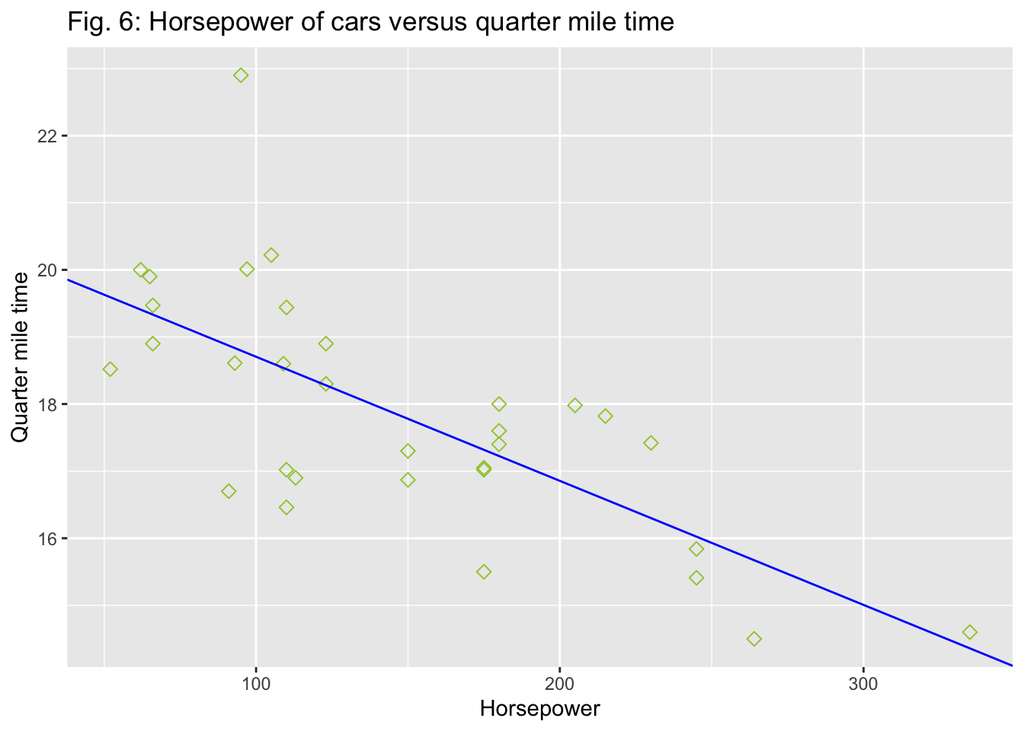

```r
ggplot(mtcars, aes(x=mtcars$hp, y=mtcars$qsec)) + geom_point(shape = 5, color=("#A2C93A"), size=2) + labs(x="Horsepower", y="Quarter mile time", title = "Fig. 6: Horsepower of cars versus quarter mile time")  + geom_abline(intercept = 20.5564, slope = -0.0185, color="blue")
```

## Line equation

y = 20.5564 - 0.0185x

## Quater mile time for a 300 hp car

```r
hp<-300
qt = 20.5564 - 0.0185*hp
qt
```

```
## [1] 15.0064
```

The estimated quater mile time for a car with 300 horsepower is 15.01 seconds.

## Significance

There is a significant negative correlation between the quarter mile time and the horsepower of cars with p=5.766e-06.

```r
library("gvlma")

gvlma(qsec~hp, data=mtcars)
```

```
##
## Call:
## lm(formula = qsec ~ hp, data = mtcars)
##
## Coefficients:
## (Intercept)           hp
##    20.55635     -0.01846
##
##
## ASSESSMENT OF THE LINEAR MODEL ASSUMPTIONS
## USING THE GLOBAL TEST ON 4 DEGREES-OF-FREEDOM:
## Level of Significance =  0.05
##
## Call:
##  gvlma(x = qsec ~ hp, data = mtcars)
##
##                       Value p-value                   Decision
## Global Stat        8.148631 0.08628    Assumptions acceptable.
## Skewness           2.876131 0.08990    Assumptions acceptable.
## Kurtosis           4.338691 0.03726 Assumptions NOT satisfied!
## Link Function      0.001639 0.96771    Assumptions acceptable.
## Heteroscedasticity 0.932170 0.33430    Assumptions acceptable.
```

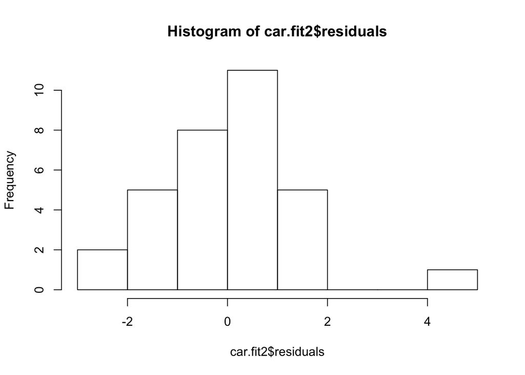

```r
hist(car.fit2$residuals)
```

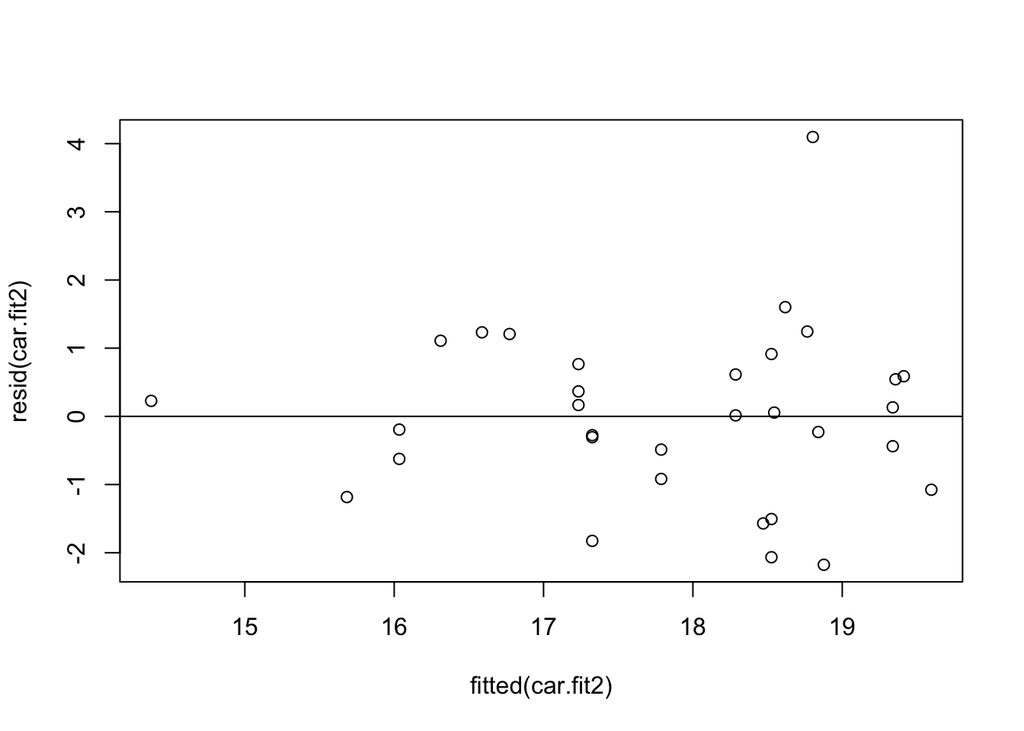

```r
plot(fitted(car.fit2),resid(car.fit2))
abline(0,0)
```

The Kurtosis assumption is not satisfied for this data and based on the histogram of the residuals, this may be due to the data not being sufficiently normally distributed.

## Question 15

The bacteria_genetics.csv includes genome size and gene number for a number of bacteria in the phylum Tenericutes and the order Erysipelotrichales (phylum Firmicutes) from my M.Sc. thesis work.

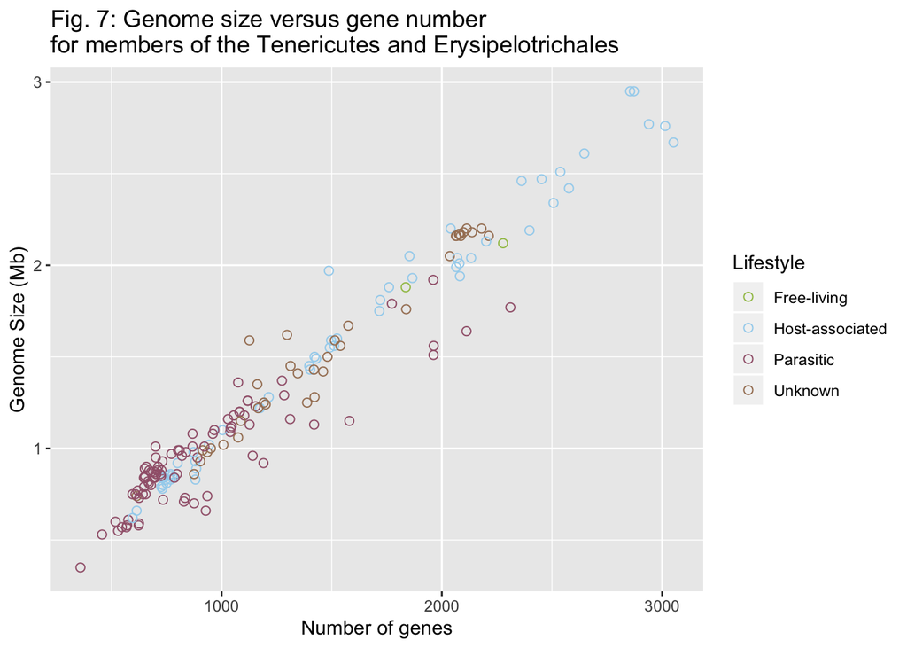

```r
bac<-read.csv("bacteria_genetics.csv")
Lifestyle<-bac$Lifestyle
library("ggplot2")
ggplot(bac, aes(x=bac$Gene_Count , y=bac$Genome_Size, color=Lifestyle)) + geom_point(shape = 1, size=2) + labs(x="Number of genes", y="Genome Size (Mb)", title = "Fig. 7: Genome size versus gene number \nfor members of the Tenericutes and Erysipelotrichales") + scale_color_manual(values = c("#A2C257","#A4D3EE","#A2627A","#A68064"))
```

```r
summary(lm(bac$Genome_Size~bac$Gene_Count))
```

```
##
## Call:
## lm(formula = bac$Genome_Size ~ bac$Gene_Count)
##
## Residuals:
##      Min       1Q   Median       3Q      Max
## -0.47581 -0.04461  0.01308  0.06817  0.46306
##
## Coefficients:
##                 Estimate Std. Error t value Pr(>|t|)
## (Intercept)    1.736e-01  2.204e-02   7.875 3.09e-13 ***
## bac$Gene_Count 8.967e-04  1.579e-05  56.795  < 2e-16 ***
## ---
## Signif. codes:  0 '***' 0.001 '**' 0.01 '*' 0.05 '.' 0.1 ' ' 1
##
## Residual standard error: 0.1337 on 180 degrees of freedom
## Multiple R-squared:  0.9471, Adjusted R-squared:  0.9469
## F-statistic:  3226 on 1 and 180 DF,  p-value: < 2.2e-16
```

```r
r=sqrt(0.9471)
r
```

```
## [1] 0.9731906
```

The correlation coefficient is r=0.973. Since p< 2e-16 for the slope, the correlation between genome size and gene number is significant.